# Rowley_Mid-Term

Brock Rowley

4/20/2020

# Part A: Data

## 1. Use the function to download all the data from 2014-15 to each of the past 4 school years and bind it into a single data frame, using a single function (i.e., one line of code).

```r
download_file <- function(year) {
    link <- glue::glue("https://www.oregon.gov/ode/educator-resources/assessment/TestResults20{year}/pagr_schools_ela_raceethnicity_{year-1}{year}.xlsx")
    rio::import(link, setclass = "tibble", na = c("-", "--", "*"))
}
years <- 15:18
data <- map_df(years, ~download_file(.x))

#Could be written as:
# map_df(years, download_file)
```

```r
names(data)
```

```
##  [1] "Academic Year"                     "District ID"
##  [3] "District"                          "School ID"
##  [5] "School"                            "Subject"
##  [7] "Student Group"                     "Grade Level"
##  [9] "Number Proficient (Level 3 or 4)"  "Percent Proficient (Level 3 or 4)"
## [11] "Number Level 4"                    "Percent Level 4"
## [13] "Number Level 3"                    "Percent Level 3"
## [15] "Number Level 2"                    "Percent Level 2"
## [17] "Number Level 1"                    "Percent Level 1"
## [19] "Number of Participants"            "Participation Rate"
## [21] "Number Proficient"
```

```r
td <- data %>%
  pivot_longer(contains("Number Level"),
  names_to = "level",
  values_to = "n") %>%
  mutate(level = str_extract(level, "[0-9]")) %>%
  select(`Academic Year`, District, School, `Student Group`, `Grade Level`, level, n) %>%
  filter(`Student Group` == "Hispanic/Latino" |
           `Student Group` == "White") %>%
  drop_na()

td <- td %>%
  janitor::clean_names()

td
```

```
## # A tibble: 90,576 x 7
##    academic_year district   school         student_group grade_level level     n
##    <chr>         <chr>      <chr>          <chr>         <chr>       <chr> <dbl>
##  1 2014-2015     Adrian SD… Adrian Elemen… Hispanic/Lat… Grade 3     4         1
##  2 2014-2015     Adrian SD… Adrian Elemen… Hispanic/Lat… Grade 3     3         2
##  3 2014-2015     Adrian SD… Adrian Elemen… Hispanic/Lat… Grade 3     2         1
##  4 2014-2015     Adrian SD… Adrian Elemen… Hispanic/Lat… Grade 3     1         2
##  5 2014-2015     Adrian SD… Adrian Elemen… Hispanic/Lat… Grade 6     4         0
##  6 2014-2015     Adrian SD… Adrian Elemen… Hispanic/Lat… Grade 6     3         2
##  7 2014-2015     Adrian SD… Adrian Elemen… Hispanic/Lat… Grade 6     2         3
##  8 2014-2015     Adrian SD… Adrian Elemen… Hispanic/Lat… Grade 6     1         2
##  9 2014-2015     Adrian SD… Adrian Elemen… Hispanic/Lat… Grade 7     4         0
## 10 2014-2015     Adrian SD… Adrian Elemen… Hispanic/Lat… Grade 7     3         2
## # … with 90,566 more rows
```

```r
# Two df's joined them together with unique schools.
unique_school <- td %>%
  group_by(district) %>%
  summarise(n_schools = length(unique(school))) %>%
  ungroup()

# Get students (n)
students <- td %>%
  group_by(district, academic_year, student_group, level) %>%
  summarise(n = sum(n)) %>%
  pivot_wider(names_from = student_group,
              values_from = n) %>%
  janitor::clean_names() %>%
  ungroup()

# Two df's joined together, drop NA, re-order the columns.
td2 <- left_join(students, unique_school) %>%
  drop_na() %>%
  select(academic_year,
         district,
         n_schools,
         level,
         hispanic_latino,
         white
         )
```

# Part B: Acheivement Gaps

## 1. (10 points) Estimate an achievement gap effect size for every school district in the state that reported data on both student groups (i.e., using the data we created above), for each academic year. Note, on my computer this took about 38 seconds. It will likely take a bit longer for you, but shouldn’t take too long. You may get a warning. Just go ahead and ignore that for now.

```r
# First four rows for first district, columns for groups.
td2[1:4, ] %>%
  gapr::estimate_v("white", "hispanic_latino")
```

```
##         auc          v       v_se
## 1 0.2824054 -0.8141778 0.07283486
```

```r
# Academic year and district as factor.
td2 <- td2 %>%
  mutate(academic_year = as.factor(academic_year))

d_split <- split(td2, td2$district)

# Do for two school districts.
sub_split <- d_split[1:2]

# This returns a factor.
sub_split[[1]]$academic_year
```

```
##  [1] 2014-2015 2014-2015 2014-2015 2014-2015 2015-2016 2015-2016 2015-2016
##  [8] 2015-2016 2016-2017 2016-2017 2016-2017 2016-2017 2017-2018 2017-2018
## [15] 2017-2018 2017-2018
## Levels: 2014-2015 2015-2016 2016-2017 2017-2018
```

```r
# This returns a tibble.
sub_split[[1]][1]
```

```
## # A tibble: 16 x 1
##    academic_year
##    <fct>
##  1 2014-2015
##  2 2014-2015
##  3 2014-2015
##  4 2014-2015
##  5 2015-2016
##  6 2015-2016
##  7 2015-2016
##  8 2015-2016
##  9 2016-2017
## 10 2016-2017
## 11 2016-2017
## 12 2016-2017
## 13 2017-2018
## 14 2017-2018
## 15 2017-2018
## 16 2017-2018
```

```r
# Nest by district and year.
by_district <- td2 %>%
    nest(-district, -academic_year, -n_schools)
# Checking with only two districts
sub_by_district_year <- td2 %>%
  filter(district == "Adrian SD 61" |
           district == "Amity SD 4J") %>%
    nest(-district, -academic_year)
```

```r
sub_by_district_year_results <- sub_by_district_year %>%
  mutate(gap = map(sub_by_district_year$data, ~estimate_v("white", "hispanic_latino",
                                  data = .x))) %>%
           select(-data) %>%
           unnest(gap)

# Moving to entire data.
results_by_district <- by_district %>%
    mutate(gap = map(by_district$data, ~estimate_v("white", "hispanic_latino",
                                                   data = .x))) %>%
           select(-data) %>%
           unnest(gap)
```

## 2. (10 points) The plot below shows the achievement gap estimate for one school district across years. Produce a similar plot to the below for each of the first 100 school districts. Make sure you don’t miss the caption noting the number of schools in the district.

Hint: You need to select unique districts.

```r
dists <- unique(results_by_district$district)[1:100]

pd <- results_by_district %>%
  filter(district %in% dists)

unique(pd$district)
```

```
##   [1] "Adrian SD 61"                    "Amity SD 4J"
##   [3] "Annex SD 29"                     "Ashland SD 5"
##   [5] "Astoria SD 1"                    "Athena-Weston SD 29RJ"
##   [7] "Baker SD 5J"                     "Bandon SD 54"
##   [9] "Banks SD 13"                     "Beaverton SD 48J"
##  [11] "Bend-LaPine Administrative SD 1" "Bethel SD 52"
##  [13] "Brookings-Harbor SD 17C"         "Butte Falls SD 91"
##  [15] "Canby SD 86"                     "Cascade SD 5"
##  [17] "Centennial SD 28J"               "Central Curry SD 1"
##  [19] "Central Linn SD 552"             "Central Point SD 6"
##  [21] "Central SD 13J"                  "Clatskanie SD 6J"
##  [23] "Coos Bay SD 9"                   "Coquille SD 8"
##  [25] "Corbett SD 39"                   "Corvallis SD 509J"
##  [27] "Creswell SD 40"                  "Crook County SD"
##  [29] "Culver SD 4"                     "Dallas SD 2"
```

[output cut: 35 more lines]

```r
# Number of rows.
pd %>% count(district)
```

```
## # A tibble: 100 x 2
##    district                  n
##    <chr>                 <int>
##  1 Adrian SD 61              4
##  2 Amity SD 4J               4
##  3 Annex SD 29               1
##  4 Ashland SD 5              4
##  5 Astoria SD 1              4
##  6 Athena-Weston SD 29RJ     4
##  7 Baker SD 5J               4
##  8 Bandon SD 54              4
##  9 Banks SD 13               4
## 10 Beaverton SD 48J          4
## # … with 90 more rows
```

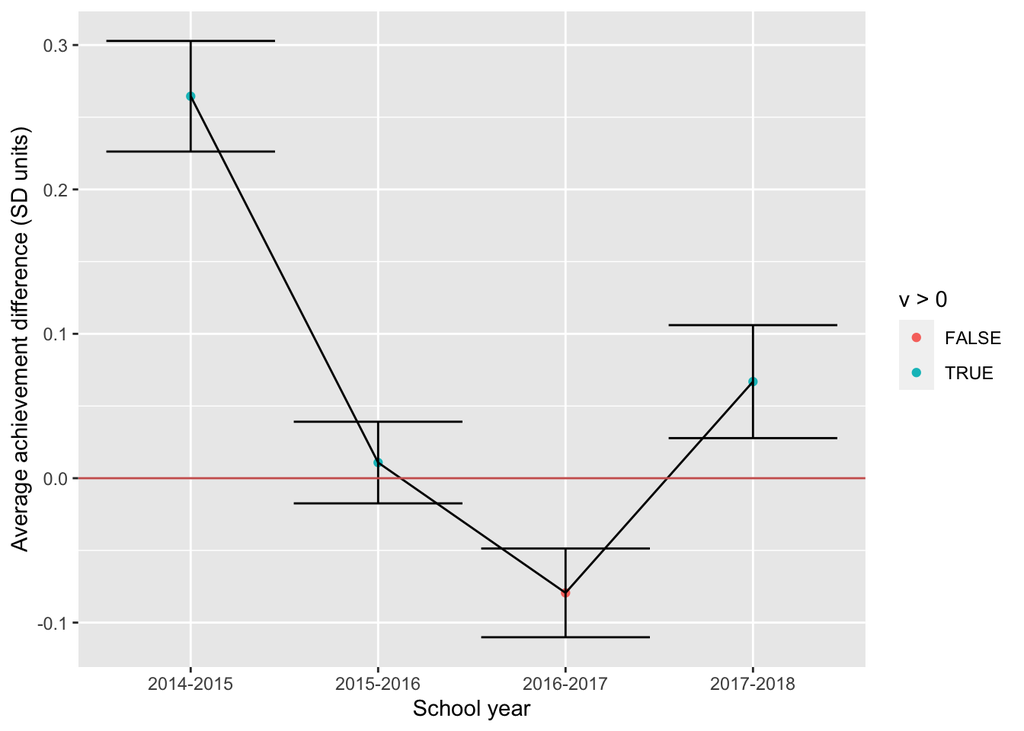

```r
pd_subset <- pd %>%
  filter(district == "Adrian SD 61" |
           district == "Amity SD 4J")

# Help from D.A. here: as.factor() makes acacdemic year a factor; then call as.numeric() to make academic_year numeric in order to get geam_line to work.
pd %>% filter(district == "Bandon SD 54") %>%
  ggplot(aes(academic_year, v)) +
  geom_point(aes(color = v > 0)) +
  geom_line(aes(x = as.numeric(as.factor(academic_year)))) +
  geom_errorbar(aes(ymin = v - v_se, ymax = v + v_se)) +
  geom_hline(yintercept = 0, color = "#CC615D") +
  labs(x = "School year",
       y = "Average achievement difference (SD units)")
```

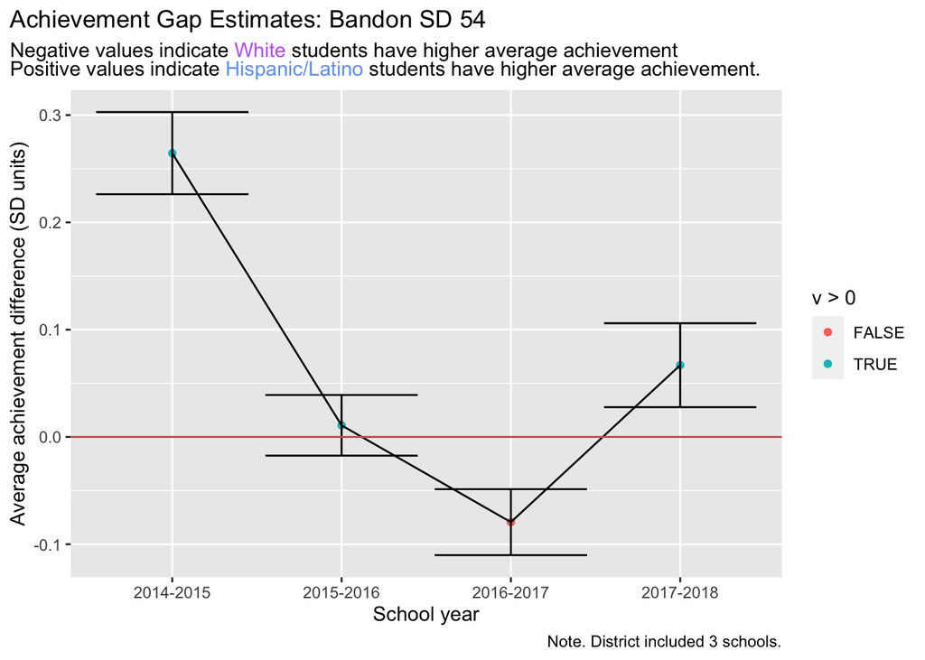

```r
# Trying with one (Bandon) school district.
pd2 <- pd %>%
    mutate(label =
    glue("Note. District included {(n_schools)} schools."))

tmp_pd <- pd2 %>%
  filter(district == "Bandon SD 54")

ggplot(tmp_pd, aes(academic_year, v)) +
  geom_point(aes(color = v > 0)) +
  geom_line(aes(x = as.numeric(as.factor(academic_year)))) +
  geom_errorbar(aes(ymin = v - v_se, ymax = v + v_se)) +
  geom_hline(yintercept = 0, color = "#CC615D") +
  theme(
    plot.title.position = "plot",
    plot.subtitle = element_markdown()) +
  labs(x = "School year",
       y = "Average achievement difference (SD units)",
       title = glue("Achievement Gap Estimates: {(tmp_pd$district)}"),
       subtitle = "Negative values indicate <span style = 'color:#C468F7;'>White</span> students have higher average achievement
       Positive values indicate <span style = 'color:#6DA3F9;'>Hispanic/Latino</span> students have higher average achievement.",
       caption = unique(tmp_pd$label))
```

```r
# Nest data to loop through lists for all plots.
pd2 %>%
    group_by(district, label) %>%
    nest()
```

```
## # A tibble: 100 x 3
## # Groups:   district, label [100]
##    district              label                               data
##    <chr>                 <glue>                              <list>
##  1 Adrian SD 61          Note. District included 2 schools.  <tibble [4 × 5]>
##  2 Amity SD 4J           Note. District included 3 schools.  <tibble [4 × 5]>
##  3 Annex SD 29           Note. District included 1 schools.  <tibble [1 × 5]>
##  4 Ashland SD 5          Note. District included 6 schools.  <tibble [4 × 5]>
##  5 Astoria SD 1          Note. District included 3 schools.  <tibble [4 × 5]>
##  6 Athena-Weston SD 29RJ Note. District included 3 schools.  <tibble [4 × 5]>
##  7 Baker SD 5J           Note. District included 8 schools.  <tibble [4 × 5]>
##  8 Bandon SD 54          Note. District included 3 schools.  <tibble [4 × 5]>
##  9 Banks SD 13           Note. District included 4 schools.  <tibble [4 × 5]>
## 10 Beaverton SD 48J      Note. District included 54 schools. <tibble [4 × 5]>
## # … with 90 more rows
```

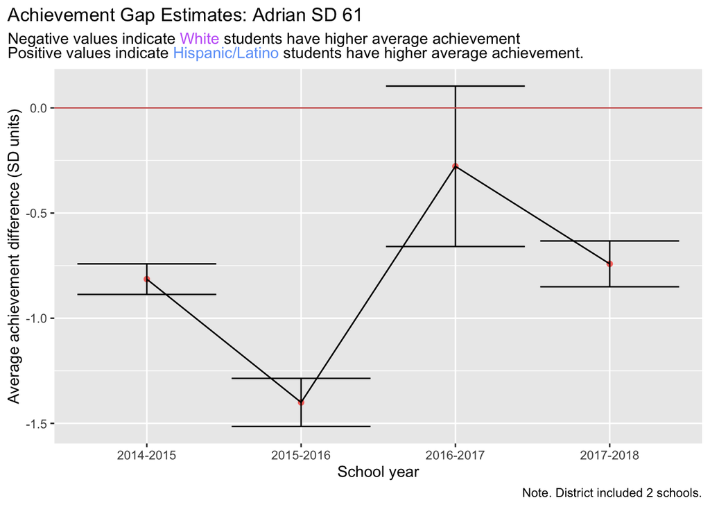

```r
final_plots <- pd2 %>%
    group_by(district, label) %>%
    nest() %>%
    mutate(plots = pmap(list(district, label, data),
    ~ggplot(..3, aes(academic_year, v), show.legend = FALSE) +
        geom_point(aes(color = v > 0), show.legend = FALSE) +
    geom_line(aes(x = as.numeric(as.factor(academic_year)))) +
    geom_errorbar(aes(ymin = v - v_se, ymax = v + v_se)) +
    geom_hline(yintercept = 0, color = "#CC615D") +
    theme(
    plot.title.position = "plot",
    plot.subtitle = element_markdown()) +
  labs(x = "School year",
       y = "Average achievement difference (SD units)",
       title = glue("Achievement Gap Estimates: {(pd2$district)}"),
       subtitle = "Negative values indicate <span style = 'color:#C468F7;'>White</span> students have higher average achievement
       Positive values indicate <span style = 'color:#6DA3F9;'>Hispanic/Latino</span> students have higher average achievement.",
       caption = unique(pd2$label))))

# Look at the plots:
final_plots$plots[[1]]
```

## 3. (10 points) Save the plots into a “plots” directory. Make sure the file names are meaningful.